# MyWebpage

Peter Omasta

3/9/2020

```r
#to be deleted once test
us_renew <- read_csv(here("data", "renewables_cons_prod.csv")) %>%
  clean_names()
us_renew <- read_csv(here("data", "renewables_cons_prod.csv")) %>%
  clean_names()
```

Explore the data frame:

```r
# View(us_renew)
# names(us_renew)
# unique(us_renew$description)
```

We’ll focus on consumption data.

### Clean up data

- Convert description to all lowercase
- Only keep observations for “consumption”
- Remove any “total” observations

```r
renew_clean <- us_renew %>%
  mutate(description = str_to_lower(description)) %>%
  filter(str_detect(description, pattern = "consumption")) %>%
  filter(!str_detect(description, pattern = "total"))
```

### Convert `yyyymm` column to date with `lubridate`

```r
renew_date <- renew_clean %>%
  mutate(yr_mo_day = lubridate::parse_date_time(yyyymm, "ym")) %>%
  mutate(month_sep = yearmonth(yr_mo_day)) %>% #coerce to tsibble `yearmonth` format
  mutate(value = as.numeric(value)) %>%
  drop_na(month_sep, value)
# Want to parse the year and month? We may use this later...
renew_parsed <-renew_date %>%
  mutate(month = month(yr_mo_day, label = TRUE)) %>%
  mutate(year = year(yr_mo_day))
```

### Make a ggplot

Make, then save, the baseline plot as `renew_gg`:

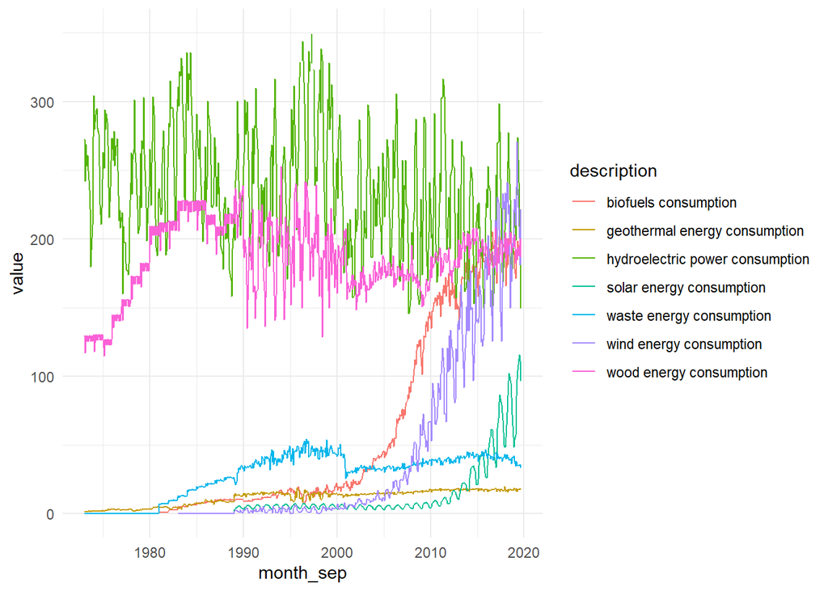

```r
renew_gg <- ggplot(data = renew_date, aes(x = month_sep, y = value, group = description)) +
  geom_line(aes(color = description)) +
  theme_minimal() +
  scale_y_continuous(limits = c(0, 350))

renew_gg
```

Now try updating your color palette using options from paletteer. Use `View(palettes_d_names)` to see all of the discrete scale options. We’ll want a palette with at least 7 colors (length >= 7). Find a name of a palette that you like, then update your graph by adding `scale_color_paletteer_d("package::palette")`. Like, if I want to use the `calecopal::figmtn` palette, I’d add:

`renew_gg + scale_color_paletteer_d("calecopal::figmtn")`

Try some out!

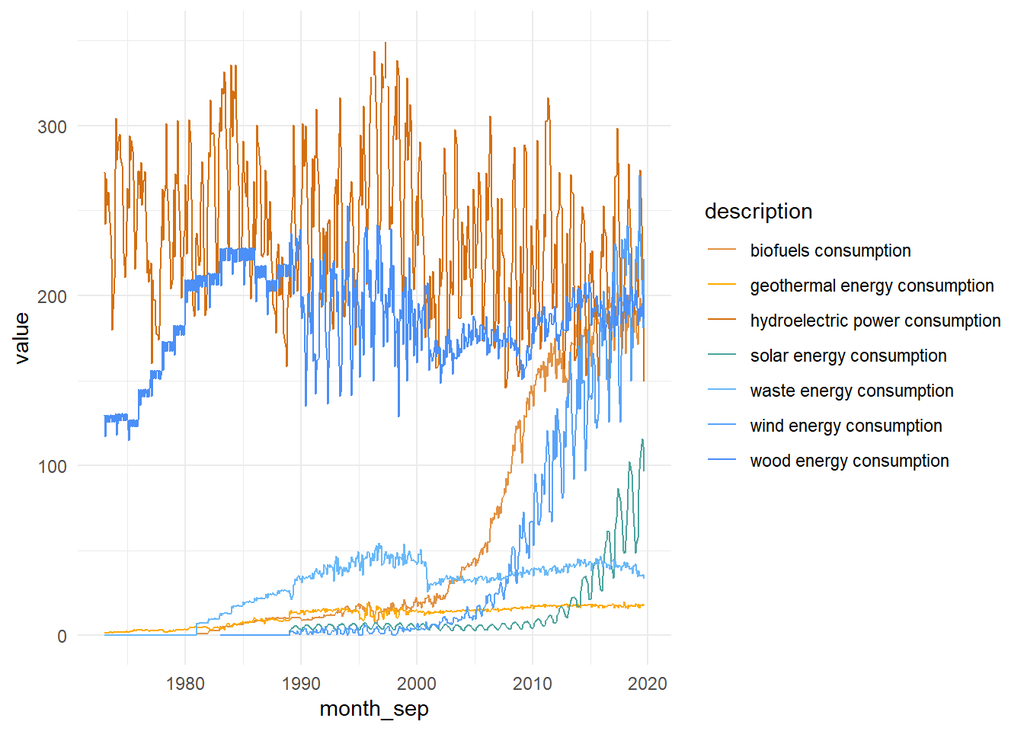

```r
renew_gg +
  scale_color_paletteer_d("calecopal::figmtn")
```

Have some fun trying out different color palettes.

### Coerce to a tsibble:

```r
renew_ts <- as_tsibble(renew_parsed, key = description, index = month_sep)
```

### Look at the data in a few different ways:

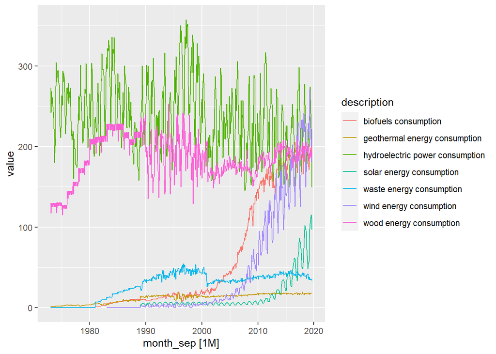

```r
renew_ts %>% autoplot(value)
```

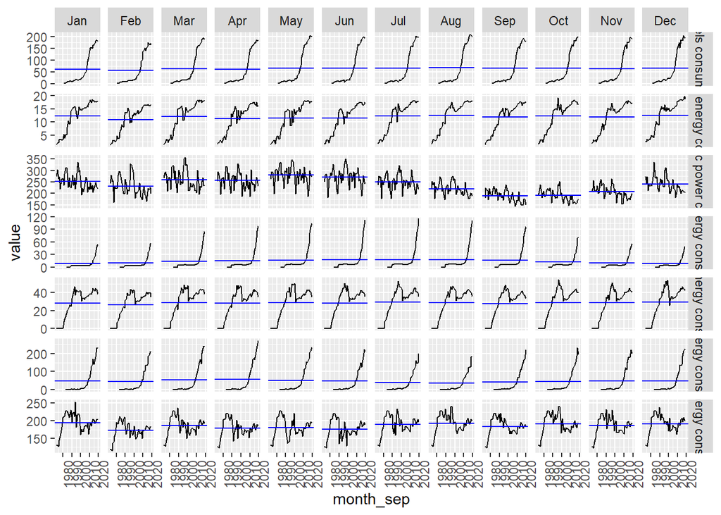

```r
renew_ts %>% gg_subseries(value)
```

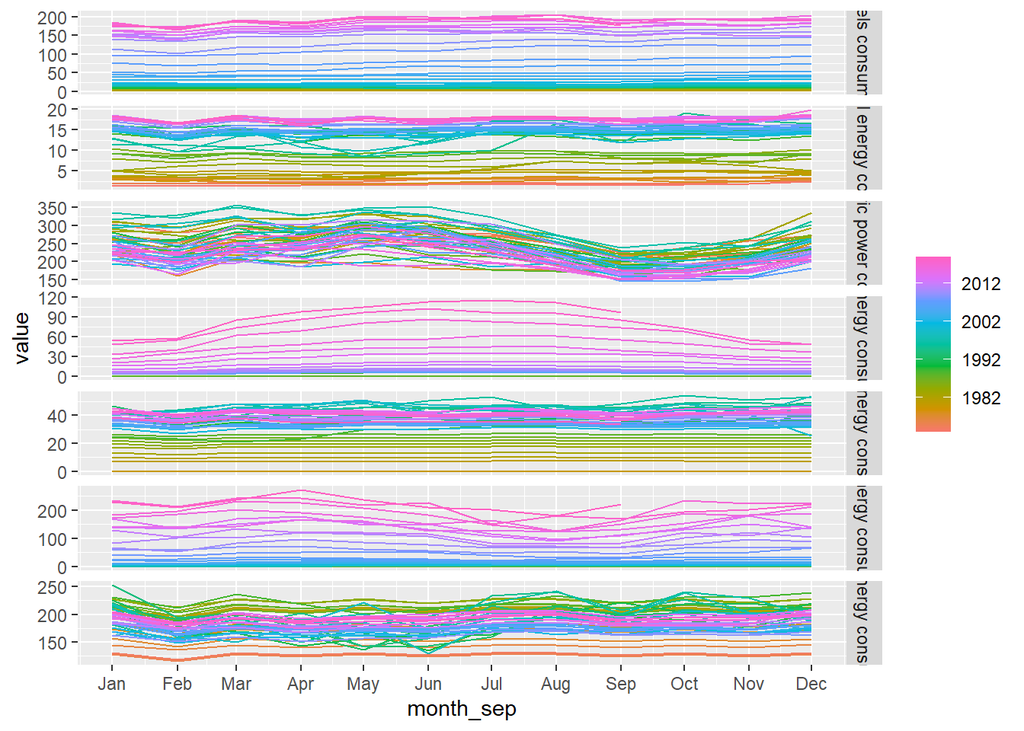

```r
renew_ts %>% gg_season(value)
```

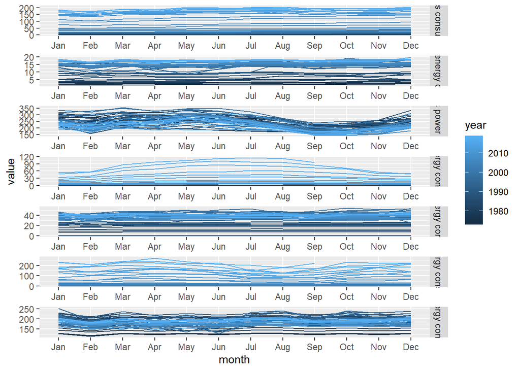

```r
# What if gg_season() didn't work? Well we can make this with ggplot anyway!
# Remember our other parsed version (renew parsed):

ggplot(data = renew_parsed, aes(x = month, y = value, group = year)) +
  geom_line(aes(color = year)) +
  facet_wrap(~ description,
             ncol = 1,
             scales = "free",
             strip.position = "right")
```

### Get just the hydroelectric energy consumption data:

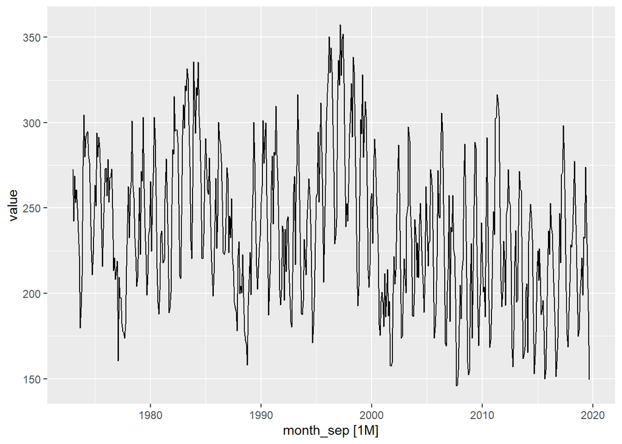

```r
hydro_ts <- renew_ts %>%
  filter(description == "hydroelectric power consumption")

# Explore:
hydro_ts %>% autoplot(value)
```

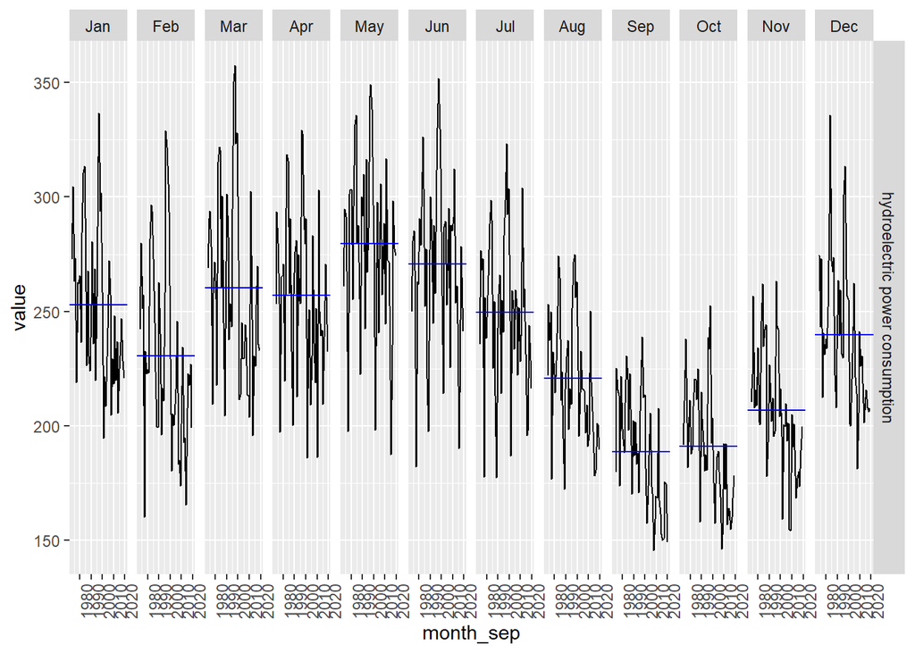

```r
hydro_ts %>% gg_subseries(value)
```

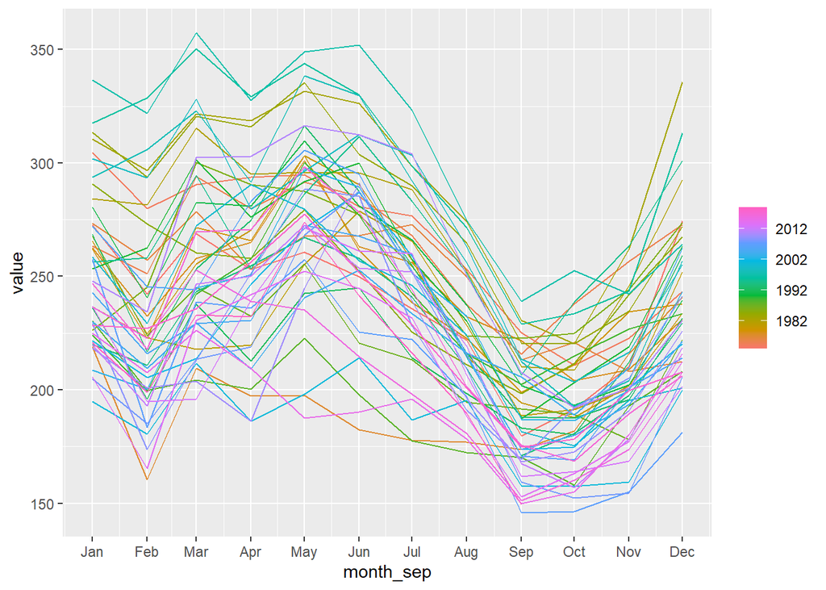

```r
hydro_ts %>% gg_season(value)
```

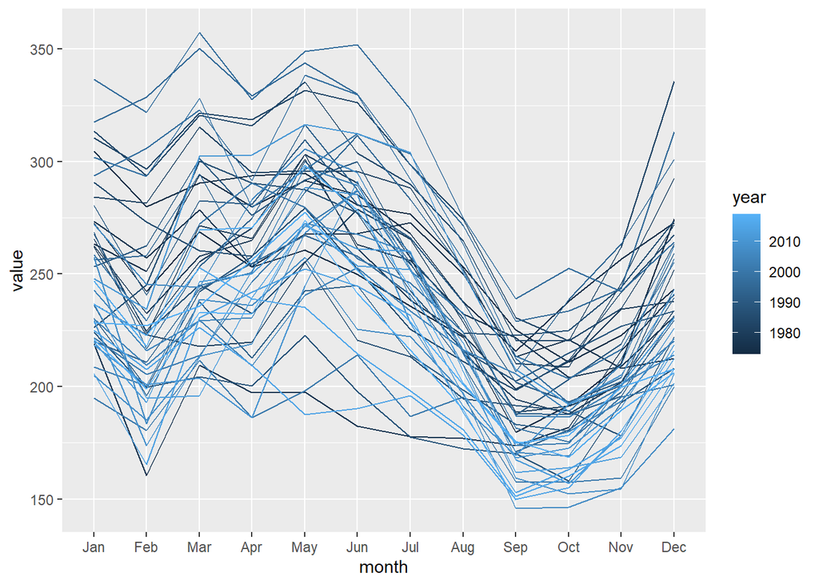

```r
# OK, what if gg_season() doesn't work?
# It's just a function that uses ggplot() to do things we already know how to do in ggplot()!
ggplot(hydro_ts, aes(x = month, y = value, group = year)) +
  geom_line(aes(color = year))
```

### Calculate summary data by time using `index_by()`

What if we want to calculate consumption by quarter? We’ll use `index_by()` to tell R which “windows” to calculate a value with in.

Quarterly:

```r
hydro_quarterly <- hydro_ts %>%
  index_by(year_qu = ~ yearquarter(.)) %>% # monthly aggregates
  summarise(
    avg_consumption = mean(value)
  )

head(hydro_quarterly)
```

```
## # A tsibble: 6 x 2 [1Q]
##   year_qu avg_consumption
##     <qtr>           <dbl>
## 1 1973 Q1            261.
## 2 1973 Q2            255.
## 3 1973 Q3            212.
## 4 1973 Q4            225.
## 5 1974 Q1            292.
## 6 1974 Q2            290.
```

Or annually:

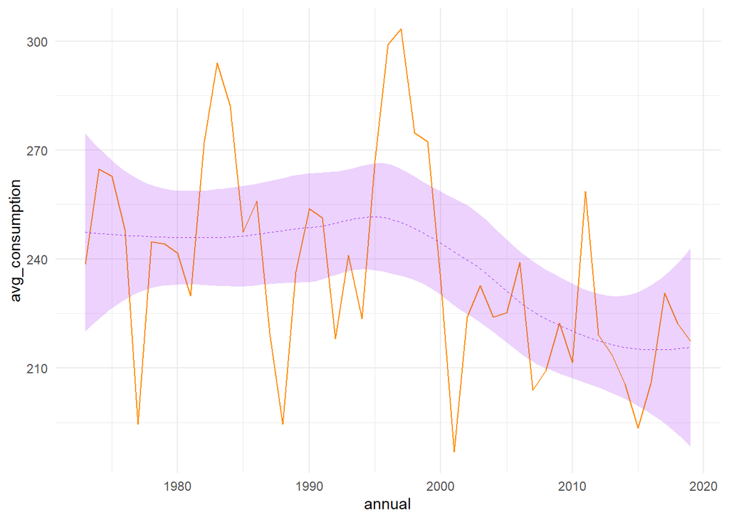

```r
hydro_annual <- hydro_ts %>%
  index_by(annual = ~year(.)) %>%
  summarize(
    avg_consumption = mean(value)
  )

ggplot(data = hydro_annual, aes(x = annual, y = avg_consumption)) +
  geom_line(color = "darkorange") +
  geom_smooth(color = "purple",
              size = 0.2,
              linetype = "dashed",
              fill = "purple",
              alpha = 0.2) +
  theme_minimal()
```

And if you have higher interval data (e.g. hourly), then you can calculate summaries by week, month, etc. using functions from `tsibble` like:

- `yearweek`
- `yearmonth`

### Decompose the hydro consumption ts data

First, let’s check the decomposition (STL):

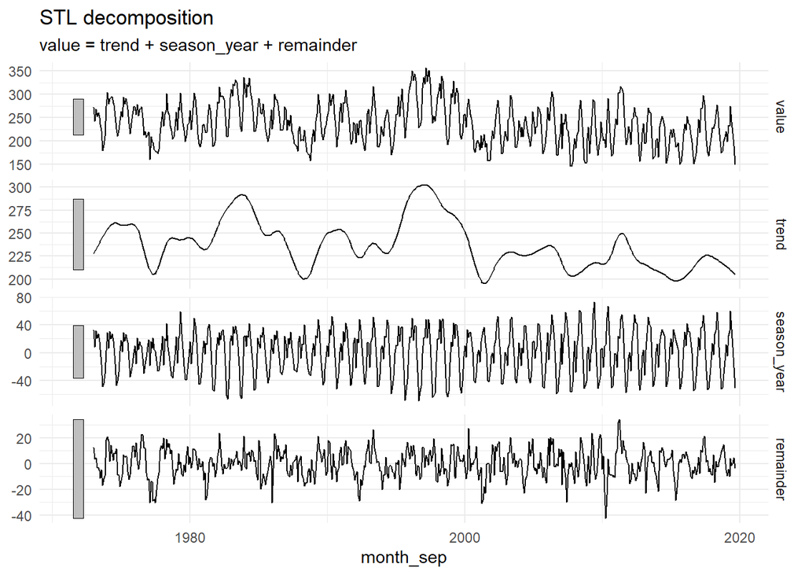

```r
# Find STL decomposition
dcmp <- hydro_ts %>%
  model(STL(value ~ season(window = 5)))

# View the components
# components(dcmp)

# Visualize the decomposed components
components(dcmp) %>% autoplot() +
  theme_minimal()
```

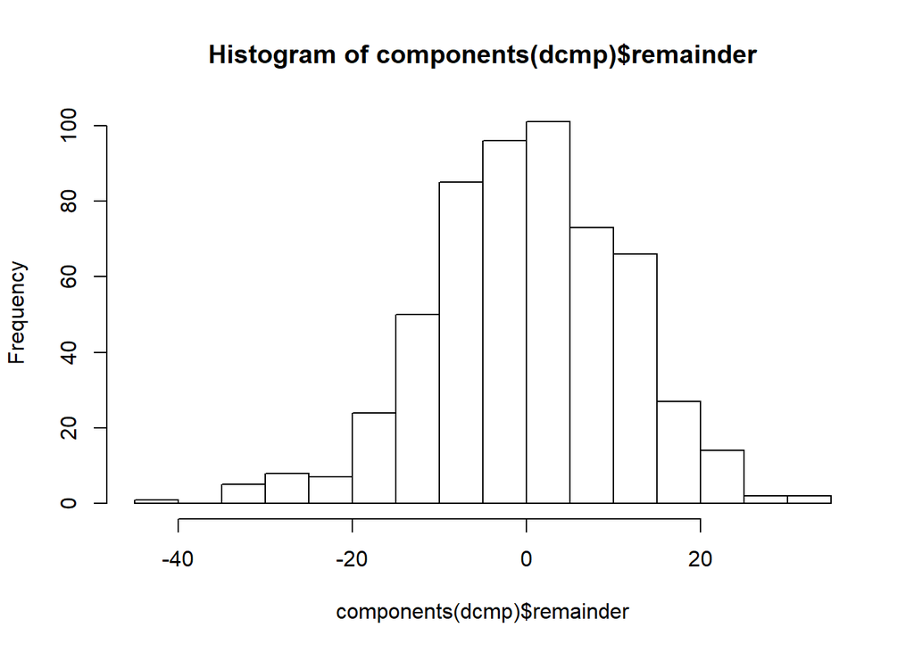

```r
# Let's check out the residuals:
hist(components(dcmp)$remainder)
```

### Explore the ACF

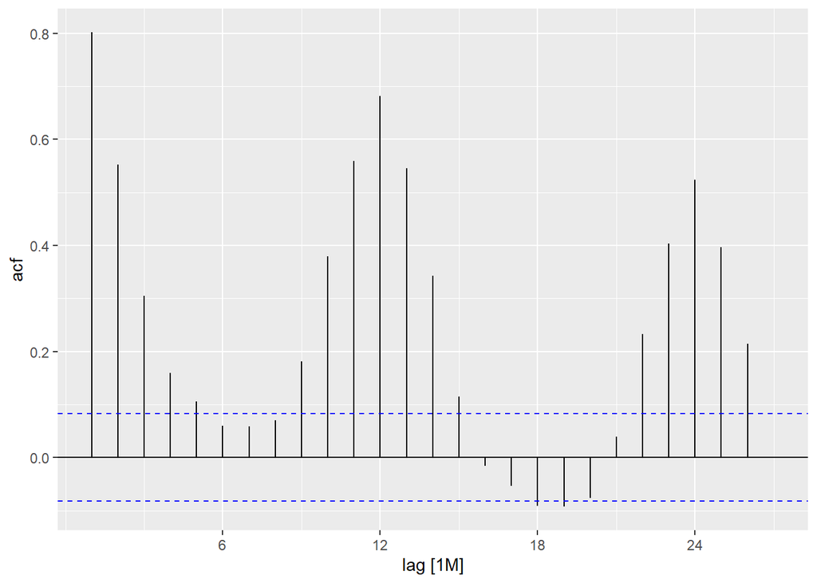

```r
hydro_ts %>%
  ACF(value) %>%
  autoplot()
```

We see peaks at 12 months: annual-difference similarities in consumption.

### Forecast future hydro power consumption

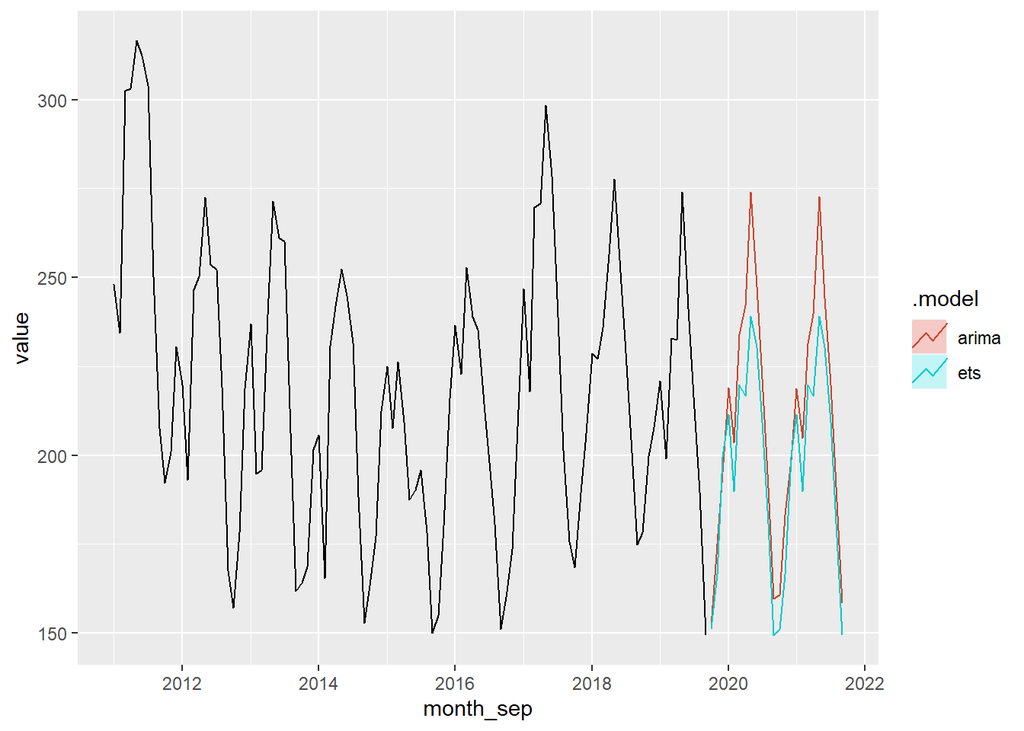

```r
hydro_model <- hydro_ts %>%
  model(
    arima = ARIMA(value),
    ets = ETS(value)
  ) %>%
  fabletools::forecast(h = "2 years")

hydro_model %>%
  autoplot(filter(hydro_ts,
                  year(month_sep) > 2010),
           level = NULL)
```

## Map-of-the-day

```r
# Get spatial data:
world <- read_sf(dsn = here("data","TM_WORLD_BORDERS_SIMPL-0.3-1"), layer = "TM_WORLD_BORDERS_SIMPL-0.3") %>% clean_names()

# Quick & easy option to see those polygons (also for points, lines!)
mapview(world)
```

[interactive chart not shown]

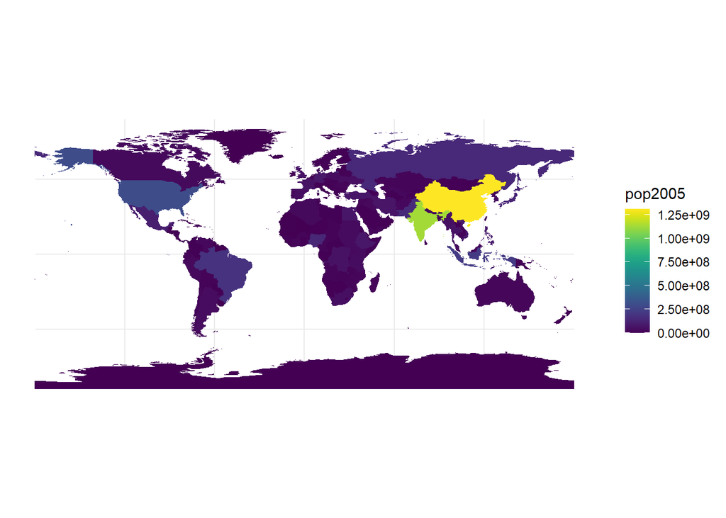

```r
# ggplot (static)
world_base <- ggplot(data = world) +
  geom_sf(aes(fill = pop2005),
          color = NA) +
  scale_fill_paletteer_c("viridis::viridis") +
  theme_minimal()

world_base
```

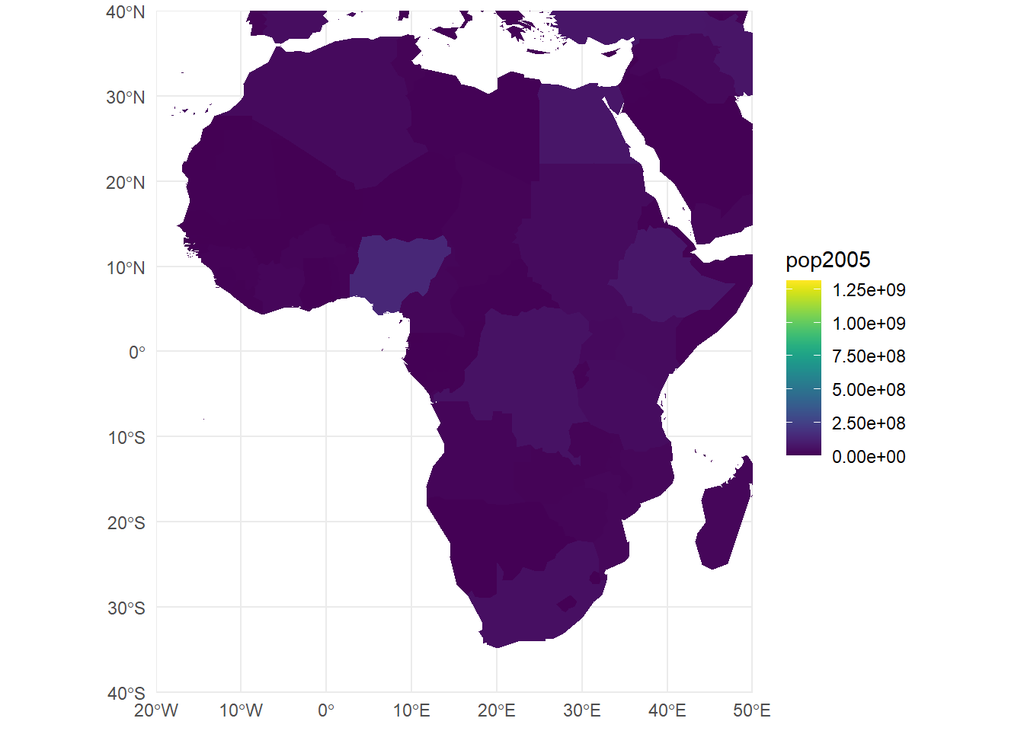

```r
# Let's crop it:
world_base +
  coord_sf(xlim = c(-20, 50), ylim = c(-40, 40), expand = FALSE)
```

## Making this a web page:

- Knit to create the html
- Push all updates back to GitHub

Since you are working in a gh-pages branch, this can be a webpage!

- Go to your-github-username.github.io/repo-name/file-name-prefix
- You should see the webpage containing your knitted document!
- Troubleshooting: - Don’t including a trailing slash (404 error) - Don’t include the .Rmd extension (will ask to download .Rmd)